# Machine Learning

### Lecture 7: Ensembles

## Learning Outcomes

- understand bias-variace trade-off in machine learning
- get familiar with ensembling methods, their differences, similarities and motivation
- understand random forest model

# Intro: Motivation

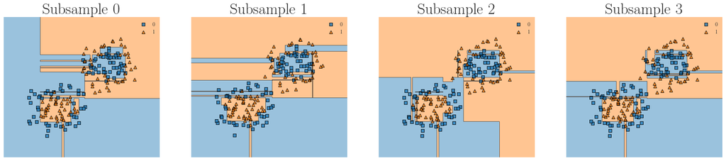

```python
fig, ax = plt.subplots(ncols=4, figsize=(25, 5))
for i in range(4):
    np.random.seed(i)
    X_part, y_part = select_subsample(X_toy, y_toy)
    dt = DecisionTreeClassifier(random_state=13)
    dt.fit(X_part, y_part)
    ax[i].set_title('Subsample {}'.format(i))
    ax[i].axis('off')
    plot_decision_regions(X_part, y_part, dt, ax=ax[i])
```

# Bias-Variance Trade-off

#### Setup: regression with quadratic loss

- We would like to approximate $f$ - function which connects feature vector $x$ and real-valued target $y$: \begin{align} y &= f(x) + \varepsilon\\ x &\sim p(x) \\ \varepsilon &\sim p(\varepsilon), \quad \mathbb{E}(\varepsilon) = 0 \end{align}
- Dataset $$ \mathbb{X} = \{x_n, y_n \}_{n=1}^N - \text{i.i.d. samples from } p(x, y)\\ $$
- We fit model $a$ using a given dataset $\mathbb{X}$:

$$ a^* = \arg\min_a \frac{1}{N} \sum_n (y_n - a(x_n))^2 $$

- If we observe a slightly different dataset, the resulting model will be different as well:

$$a^*(x) \Rightarrow a^*_{\mathbb{X}}(x)$$

#### How to measure error of $a$ independent of $\mathbb{X}$?

$$ \mathcal{R}(a) = \mathbb{E}_{\mathbb{X}} \mathbb{E}_{p(x, y)} \left[ (y - a_{\mathbb{X}}(x))^2 \right] $$

- **Trick 1. Inner expectation:** $ \pm f(x)$ and open the brackets: $$ \mathbb{E}_{p(x, y)} \left[ (y - a_{\mathbb{X}}(x))^2 \right] = \mathbb{E}_{p(x, y)} \left[ (y - f(x) + f(x) - a_{\mathbb{X}}(x))^2 \right] = \\ \mathbb{E}_{p(x, y)} \left[(y - f(x))^2\right] + 2 \mathbb{E}_{p(x, y)} \left[ (y - f(x)) (f(x) - a_{\mathbb{X}}(x))\right] + \mathbb{E}_{p(x, y)} \left[(f(x) - a_{\mathbb{X}}(x))^2\right] =\\ \mathbb{V}(\varepsilon) + 0 + \mathbb{E}_{p(x, y)} \left[(f(x) - a_{\mathbb{X}}(x))^2\right] $$
- Plug back: $$ \mathcal{R}(a) = \mathbb{E}_{\mathbb{X}}\left[ \mathbb{V}(\varepsilon) + \mathbb{E}_{p(x, y)} \left[(f(x) - a_{\mathbb{X}}(x))^2\right]\right] = \mathbb{V}(\varepsilon) + \mathbb{E}_{\mathbb{X}} \mathbb{E}_{p(x, y)} \left[(f(x) - a_{\mathbb{X}}(x))^2\right] $$

#### How to measure error of $a$ independent of $\mathbb{X}$?

$$ \mathcal{R}(a) = \mathbb{E}_{\mathbb{X}} \mathbb{E}_{p(x, y)} \left[ (y - a_{\mathbb{X}}(x))^2 \right] $$

- **Trick 1. Inner expectation:** $ \pm f(x)$ and open the brackets:

$$ \mathcal{R}(a) = \mathbb{E}_{\mathbb{X}}\left[ \mathbb{V}(\varepsilon) + \mathbb{E}_{p(x, y)} \left[(f(x) - a_{\mathbb{X}}(x))^2\right]\right] = \mathbb{V}(\varepsilon) + \mathbb{E}_{\mathbb{X}} \mathbb{E}_{p(x, y)} \left[(f(x) - a_{\mathbb{X}}(x))^2\right] $$

- **Trick 2. Second term:** swap expectations, $\pm \mathbb{E}_{\mathbb{X}}a_{\mathbb{X}}(x)$ and open the brackets:

$$ \mathbb{E}_{\mathbb{X}}\left[(f(x) - \mathbb{E}_{\mathbb{X}}a_{\mathbb{X}}(x) + \mathbb{E}_{\mathbb{X}}a_{\mathbb{X}}(x) - a_{\mathbb{X}}(x))^2\right] = \mathbb{E}_{\mathbb{X}}\left[ (f(x) - \mathbb{E}_{\mathbb{X}}a_{\mathbb{X}}(x))^2 \right] + \mathbb{E}_{\mathbb{X}}\left[ ( \mathbb{E}_{\mathbb{X}}a_{\mathbb{X}}(x) - a_{\mathbb{X}}(x))^2 \right] = \\ (f(x) - \mathbb{E}_{\mathbb{X}}a_{\mathbb{X}}(x))^2 + \mathbb{V}( a_{\mathbb{X}}(x)) $$

- All together:

$$ \mathcal{R}(a) = \mathbb{V}(\varepsilon) + \mathbb{E}_{p(x, y)} \left[ (f(x) - \mathbb{E}_{\mathbb{X}}a_{\mathbb{X}}(x))^2 \right] + \mathbb{E}_{p(x, y)} \left[ \mathbb{V}( a_{\mathbb{X}}(x)) \right] $$

Expexted error = Irreducible noise + Bias^2 + Variance

The same can be derived for classification: [link](https://www.jmlr.org/papers/volume5/valentini04a/valentini04a.pdf)

$$ \text{Bias}^2 = \mathbb{E}_{p(x, y)} \left[ (f(x) - \mathbb{E}_{\mathbb{X}}a_{\mathbb{X}}(x))^2 \right] \\ \text{Variance} = \mathbb{E}_{p(x, y)} \left[ \mathbb{V}( a_{\mathbb{X}}(x)) \right] $$

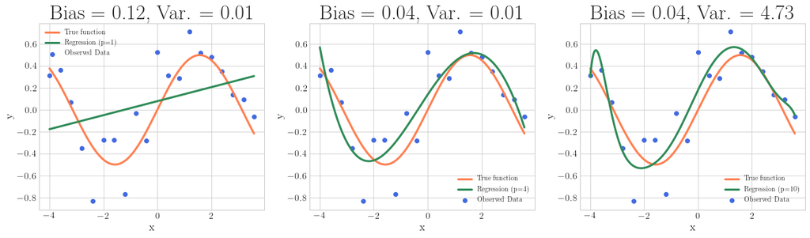

```python
fig, ax = plt.subplots(ncols=3, figsize=(20,5))

for i, p in enumerate([1, 4, 10]):
    plot_real_fun(ax[i])
    plot_poly_reg(x, y, p, name='Regression (p={})'.format(p), ax=ax[i])

    b, v = estimate_bias_variance(make_pow(x_grid, p), y_grid, LinearRegression())
    ax[i].set_title('Bias = {:.2f}, Var. = {:.2f}'.format(b, v))
    ax[i].legend()
```

$$ \text{Bias}^2 = \mathbb{E}_{p(x, y)} \left[ (f(x) - \mathbb{E}_{\mathbb{X}}a_{\mathbb{X}}(x))^2 \right] \\ \text{Variance} = \mathbb{E}_{p(x, y)} \left[ \mathbb{V}( a_{\mathbb{X}}(x)) \right] $$

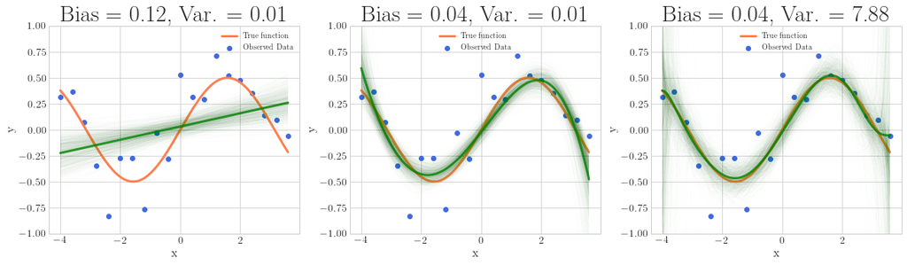

```python
fig, ax = plt.subplots(ncols=3, figsize=(20,5))

for i, p in enumerate([1, 4, 10]):
    plot_real_fun(ax[i])
    plot_variance(make_pow(x_grid, p), y_grid, LinearRegression(), ax=ax[i])
    b, v = estimate_bias_variance(make_pow(x_grid, p), y_grid, LinearRegression())
    ax[i].set_title('Bias = {:.2f}, Var. = {:.2f}'.format(b, v))
    ax[i].legend()
```

### Example: Predict diabetes progression

- 10 features, Lasso model

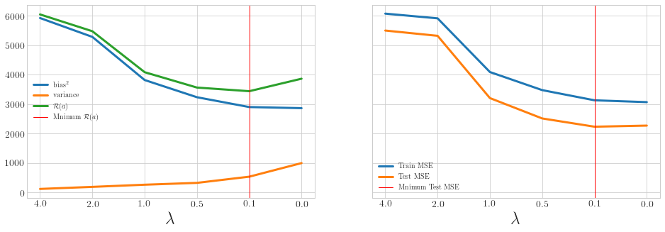

```python
fig, ax = plt.subplots(ncols=2, figsize=(16, 5), sharey=True)

ax[0].plot(bv_res[:, 0], label=r'bias$^2$')
ax[0].plot(bv_res[:, 1], label='variance')
ax[0].plot(bv_res.sum(1), label=r'$\mathcal{R}(a)$')
ax[0].axvline(x = np.argmin(bv_res.sum(1)), linewidth=1, c='r', label=r'Mnimum $\mathcal{R}(a)$')
ax[0].set_xticks(range(lbd_vals.shape[0]))
ax[0].set_xticklabels(labels=lbd_vals)
ax[0].set_xlabel(r'$\lambda$')
ax[0].legend();

ax[1].plot(fit_res[:,0], label='Train MSE')
ax[1].plot(fit_res[:,1], label='Test MSE')
ax[1].axvline(x = np.argmin(fit_res[:,1]), linewidth=1, c='r', label=r'Mnimum Test MSE')
ax[1].set_xticks(range(lbd_vals.shape[0]))
ax[1].set_xticklabels(labels=lbd_vals)
ax[1].set_xlabel(r'$\lambda$')
ax[1].legend();
```

# Ensembles

- Bagging
- Boosting
- Stacking
- Blending
- ...

### Composition of models

- Let's train $M$ base models:

$$ b_1(x), \dots, b_M(x) $$

- And create a composition

$$a_M(x) = f(b_1(x), \dots, b_M(x))$$

- E.g. by averaging their predictions:

$$a_M(x) = \frac{1}{M}\sum_{m=1}^M b_m(x)$$

### Variety of Composition Algorithms

- Do all $b_m$ come from the same familty?
  - Yes $\Rightarrow$ Bagging, Random subspaces, Boosting
  - No $\Rightarrow$ Stacking, Blending, Voting
- Do we train $b_m$ independently?
  - Yes $\Rightarrow$ Bagging, Random subspaces
  - No $\Rightarrow$ Boosting

### Base models from the same family

- $M$ base models: $b_1(x), \dots, b_M(x)$
- How to build $M$ different models using only $1$ training dataset?

Two options:

- Train on different subsamples
  - Bagging
  - Random subsamples
- Train successively to correct errors of the previous algorim
  - Boosting

### Bagging

**B**ootstrap **agg**regat**ing**

- Use Bootstrap to create a subsamples
- Train each base model on a new subsample
- Aggregate predictions:
  - Averaging for regression: $a_M(x) = \frac{1}{M}\sum_{m=1}^M b_m(x)$
  - Magority vote for classification: $a_M(x) = \arg\max_{y \in \mathbb{Y}}\sum_{m=1}^M \left[b_m(x) = y\right]$

### Bootstrap

- Create subsamples with replacement

E.g. given dataet with $N$ observations we independetly select $N$ observations (withe replacement):

$$ \{x_1, x_2, x_3, x_4\} \rightarrow \{x_2, x_1, x_2, x_4\} $$

- A new subsample will have $\approx 63.2\%$ unique observations

### Random Subspaces

- Select a random subset of features
- Train each base model on a new set of features
- May work poorly if some feature is critical for a reasonable model

### Two sources of randomness

### Bias and Variance

- $M$ base models: $b_1(x), \dots, b_M(x)$
  - independent
  - from the same family
- They have the same bias and variance. Denote: $$ \mathbb{E}_{\mathbb{X}}b_i(x) = \mu(x)\quad \forall i = 1,\dots, M \\ \mathbb{V}_{\mathbb{X}}b_i(x) = \nu(x)\quad \forall i = 1,\dots, M \\ $$

### Bias and Variance

- Bias$^2$

$$ \mathbb{E}_{p(x, y)}\left[f(x) - \mathbb{E}_{\mathbb{X}}a_{\mathbb{X}}(x) \right]^2 = \mathbb{E}_{p(x, y)}\left[f(x) - \mathbb{E}_{\mathbb{X}}\frac{1}{M}\sum_{m=1}^M b_m(x) \right]^2 = \mathbb{E}_{p(x, y)}\left[f(x) - \mu(x) \right]^2 $$

- Variance

$$ \mathbb{E}_{p(x, y)} \mathbb{V} (a_{\mathbb{X}}(x) ) = \frac{1}{M} \mathbb{E}_{p(x, y)} \nu(x) + \frac{1}{M^2}\sum_{i\neq j} \mathbb{E}_{p(x, y)} \mathbb{C}\text{ov}(b_i(x), b_j(x)) $$

- If base models are **independent** we get variance, which is $M$ times smaller with the same bias
- The more correlated models are, the smaller is effect of the ensemble

### Base Models from different families

- Voting Regressor / Classifier
  - Train $M$ different models (e.g. Linear Regression, kNN and Decision Tree)
  - Combine prediction through averagining or majority vote
- Stacking (Stacked Generalization)
  - Train $M$ different models (e.g. Linear Regression, kNN and Decision Tree)
  - $M$ new features --- predictions of the base classifiers
  - Train **final estimator** on the new features
- Blending
  - Special case of staking

# Random Forest

Bagging + Random Subsets + Decision Trees

- Decision Trees have low bias
- Bagging and Random Subsamples reduce variance

### RF algorithm

- For $m = 1, \dots, M$:
  - Sample $\widehat{X}$ via bootstrap
  - Train decision tree $b_m(x)$ on $\widehat{X}$:
    - Usually deep trees are used
    - For **each** split: select best split among random subset of features

### Without bootstrap

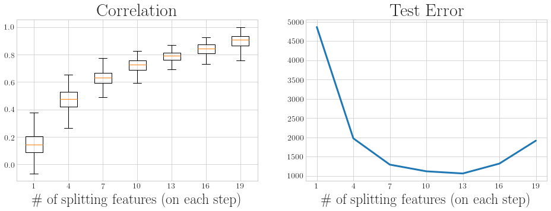

```python
fig, ax = plt.subplots(ncols=2, figsize=(16, 5))
ax[0].set_title('Correlation')
ax[0].boxplot(correlations, sym='')
ax[0].set_xticklabels(labels=ms)
ax[0].set_xlabel('\# of splitting features (on each step)')

ax[1].set_title('Test Error')
ax[1].plot(mse);
ax[1].set_xticks(range(len(mse)))
ax[1].set_xlabel('\# of splitting features (on each step)')
ax[1].set_xticklabels(labels=ms);
```

### With bootstrap

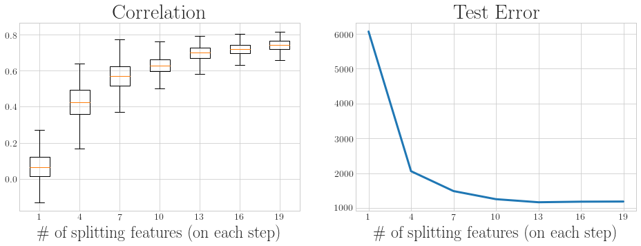

```python
fig, ax = plt.subplots(ncols=2, figsize=(16, 5))
ax[0].set_title('Correlation')
ax[0].boxplot(correlations, sym='')
ax[0].set_xticklabels(labels=ms)
ax[0].set_xlabel('\# of splitting features (on each step)')

ax[1].set_title('Test Error')
ax[1].plot(mse);
ax[1].set_xticks(range(len(mse)))
ax[1].set_xlabel('\# of splitting features (on each step)')
ax[1].set_xticklabels(labels=ms);
```

### How many trees should be there?

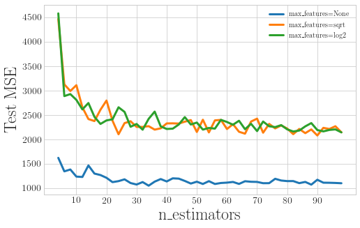

```python
for i in range(3):
    plt.plot(mse_test[i], label='max\_features='+str(ms[i]))
plt.xticks(range(len(ns))[3::5], ns[3::5])
plt.xlabel('n\_estimators')
plt.ylabel('Test MSE')
plt.legend();
```

## Learning Outcomes

- understand bias-variace trade-off in machine learning
- get familiar with ensembling methods, their differences, similarities and motivation
- understand random forest model